# Master en Big Data. Fundamentos Matemáticos del Análisis de Datos (FMAD).

Tarea 2

Departamento de Matemática Aplicada

Curso 2021-22. Última actualización: 2021-09-24

# Instrucciones preliminares

- Empieza abriendo el proyecto de RStudio correspondiente a tu repositorio personal de la asignatura.
- En todas las tareas tendrás que repetir un proceso como el descrito en la sección *Repite los pasos Creando un fichero Rmarkdown para esta práctica* de la *Práctica00*. Puedes releer la sección *Practicando la entrega de las Tareas* de esa misma práctica para recordar el procedimiento de entrega.

# Ejercicio 1. Simulando variables aleatorias discretas.

**Apartado 1:** La variable aleatoria discreta $X1$ tiene esta tabla de densidad de probabilidad (es la variable que se usa como ejemplo en la Sesión ):
$$\begin{array}{|c|c|c|c|c|c|c|}
\hline
\text{valor de }X1 & 0 & 1 & 2 & 3 \\
\hline
\text{Probabilidad de ese valor }P(X = x_i) & \dfrac{64}{125} &
\dfrac{48}{125}& \dfrac{12}{125} & \dfrac{1}{125}\rule{0mm}{6mm} \\[3mm]
\hline
\end{array}$$

Calcula la media y la varianza teóricas de esta variable.

```r
library(tidyverse)
#Definimos la variable y calculamoa la media y varianza teórica
val_x<- c(0,1,2,3)
prob_x <- c(64/125, 48/125, 12/125, 1/125)
x1<- data.frame(cbind(val_x,prob_x))
#Media teórica
media_teorica <- sum((x1$val_x)*(x1$prob_x))
media_teorica
```

```
## [1] 0.6
```

```r
#Varianza teórica
varianza_teorica <- sum(((x1$val_x)^2 - media_teorica)*(x1$prob_x))
varianza_teorica
```

```
## [1] 0.24
```

**Apartado 2:** Combina `sample` con `replicate` para simular cien mil muestras de tamaño 10 de esta variable $X1$. Estudia la distribución de las medias muestrales como hemos hecho en ejemplos previos, ilustrando con gráficas la distribución de esas medias muestrales. Cambia después el tamaño de la muestra a 30 y repite el análisis.

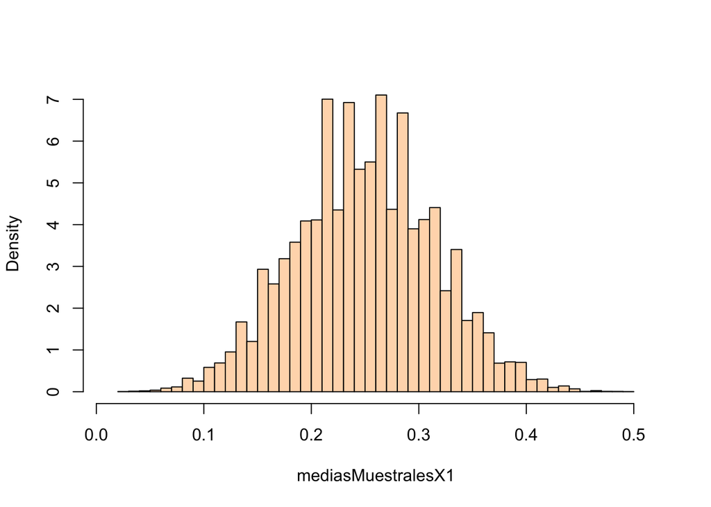

```r
k = 100000
n = 10
mediasMuestralesX1 = replicate(k, {
  muestra = sample(x1$prob_x, n, replace = TRUE)
  mean(muestra)
})
hist(mediasMuestralesX1, breaks = 40, main="",
     col="peachpuff", probability = TRUE, xlim=range(x1$prob_x))
```

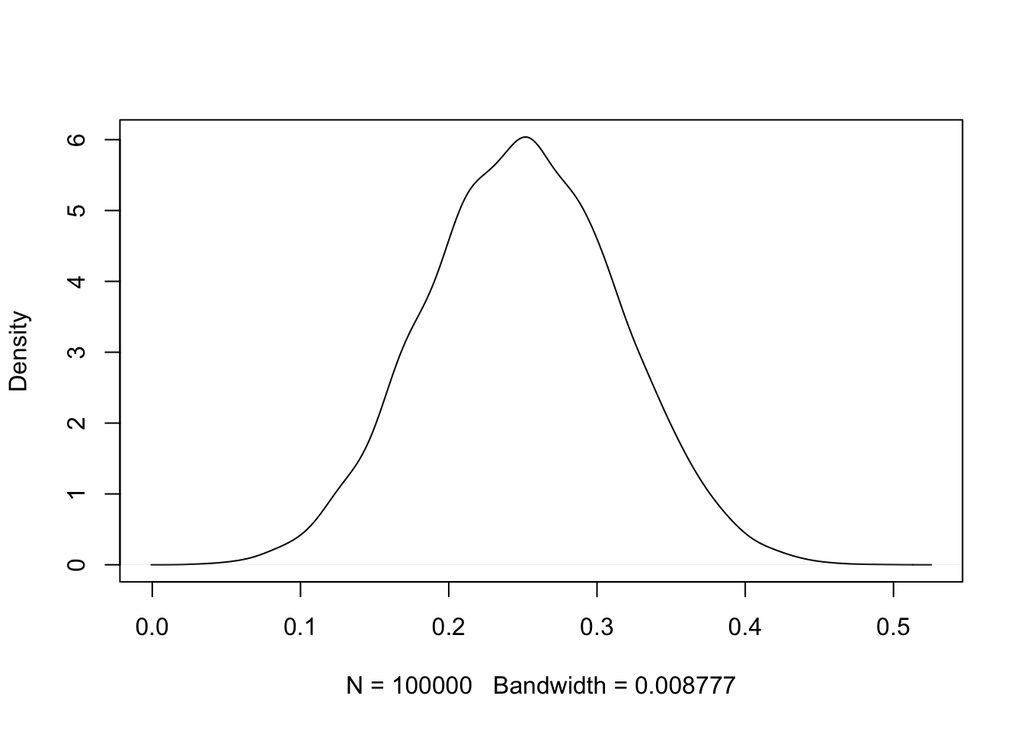

```r
plot(density(mediasMuestralesX1, adjust = 1.5), main="")
```

```r
val_x2<- c(0,1,2)
prob_x2 <- c(1/2, 1/4, 1/2)
x2<- data.frame(cbind(val_x2,prob_x2))
prob_0 <- x1$prob_x[1] * x2$prob_x2[1]
prob_0
```

```
## [1] 0.256
```

```r
prob_1 <- sum(x1$prob_x[1] * x2$prob_x2[2],x1$prob_x[2] * x2$prob_x2[1] )
prob_1
```

```
## [1] 0.32
```

```r
prob_2 <- sum(x1$prob_x[1] * x2$prob_x2[3],x1$prob_x[3] * x2$prob_x2[1],x1$prob_x[2] * x2$prob_x2[2]  )
prob_2
```

```
## [1] 0.4
```

```r
prob_3<- sum(x1$prob_x[4] * x2$prob_x2[1],x1$prob_x[2] * x2$prob_x2[3],x1$prob_x[3] * x2$prob_x2[2]  )
prob_3
```

```
## [1] 0.22
```

```r
prob_4 <- sum(x1$prob_x[4] * x2$prob_x2[1],x1$prob_x[3] * x2$prob_x2[3] )
prob_4
```

```
## [1] 0.052
```

```r
prob_5 <- x1$prob_x[4] * x2$prob_x2[2]
prob_5
```

```
## [1] 0.002
```

```r
probabilid<- c(prob_0,prob_1,prob_2,prob_3,prob_4,prob_5)
tabla_prob <- cbind(c(0:5), probabilid )
tabla_probabilidades <- data.frame(tabla_prob)
```

**Apartado 4:** Calcula la media teórica de la suma $X_1 + X_2$. Después usa `sample` y `replicate` para simular cien mil *valores* de esta variable suma. Calcula la media de esos valores. *Advertencia:* no es el mismo tipo de análisis que hemos hecho en el segundo apartado.

```r
media_teorica2 <- sum(tabla_probabilidades$V1 *(tabla_probabilidades$probabilid))
media_teorica2
```

```
## [1] 1.998
```

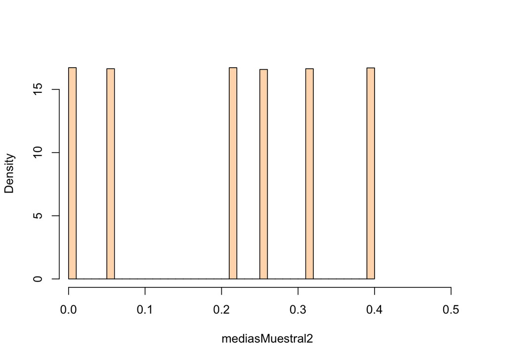

```r
k=100000
n = 1
mediasMuestral2 = replicate(k, {
  muestra2 = sample(tabla_probabilidades$probabilid, n, replace = TRUE)
  mean(muestra2)
})
hist(mediasMuestral2, breaks = 40, main="",
     col="peachpuff", probability = TRUE, xlim=range(x1$prob_x))
```

# Ejercicio 2. Datos limpios

- Descarga el fichero de este enlace

https://gist.githubusercontent.com/fernandosansegundo/471b4887737cfcec7e9cf28631f2e21e/raw/b3944599d02df494f5903740db5acac9da35bc6f/testResults.csv

- Este fichero contiene las notas de los alumnos de una clase, que hicieron dos tests cada semana durante cinco semanas. La tabla de datos no cumple los principios de *tidy data* que hemos visto en clase. Tu tarea en este ejercicio es explicar por qué no se cumplen y obtener una tabla de datos limpios con la misma información usando *tidyR*.  
  **Indicación:** lee la ayuda de la función `separate` de *tidyR*.

```r
testResult <-read.csv(url('https://gist.githubusercontent.com/fernandosansegundo/471b4887737cfcec7e9cf28631f2e21e/raw/b3944599d02df494f5903740db5acac9da35bc6f/testResults.csv'))
summary(testResult)
```

```
##      name                 id         gender_age         test_number
##  Length:200         Min.   :101.0   Length:200         Min.   :1.0
##  Class :character   1st Qu.:291.5   Class :character   1st Qu.:1.0
##  Mode  :character   Median :488.0   Mode  :character   Median :1.5
##                     Mean   :520.6                      Mean   :1.5
##                     3rd Qu.:760.0                      3rd Qu.:2.0
##                     Max.   :981.0                      Max.   :2.0
##      week1          week2           week3           week4
##  Min.   : 0.0   Min.   : 0.00   Min.   : 0.00   Min.   : 0.00
##  1st Qu.: 2.0   1st Qu.: 2.00   1st Qu.: 2.00   1st Qu.: 2.00
##  Median : 5.0   Median : 5.00   Median : 5.00   Median : 5.00
##  Mean   : 4.9   Mean   : 4.89   Mean   : 4.84   Mean   : 5.08
##  3rd Qu.: 8.0   3rd Qu.: 8.00   3rd Qu.: 7.00   3rd Qu.: 8.00
##  Max.   :10.0   Max.   :10.00   Max.   :10.00   Max.   :10.00
##      week5
##  Min.   : 0.000
##  1st Qu.: 2.000
##  Median : 5.000
##  Mean   : 4.875
##  3rd Qu.: 7.000
##  Max.   :10.000
```

```r
library(tidyr)
#No cumplen los principios de tidy data porque las filas de week no corresponden a observaciones
(testResulTidys = testResult %>%
    pivot_longer(week1:week5, names_to = "week") %>%
    separate(gender_age, c("gender", "age"), sep = "([_])")
    )
```

```
## # A tibble: 1,000 × 7
##    name     id gender age   test_number week  value
##    <chr> <int> <chr>  <chr>       <int> <chr> <int>
##  1 Jacob   108 m      20              1 week1     8
##  2 Jacob   108 m      20              1 week2     5
##  3 Jacob   108 m      20              1 week3     7
##  4 Jacob   108 m      20              1 week4     5
##  5 Jacob   108 m      20              1 week5     6
##  6 Jacob   108 m      20              2 week1     2
##  7 Jacob   108 m      20              2 week2     2
##  8 Jacob   108 m      20              2 week3     4
##  9 Jacob   108 m      20              2 week4     0
## 10 Jacob   108 m      20              2 week5     3
## # … with 990 more rows
```

```r
testResulTidys<- transform(testResulTidys, age = as.integer(age))
head(testResulTidys)
```

```
##    name  id gender age test_number  week value
## 1 Jacob 108      m  20           1 week1     8
## 2 Jacob 108      m  20           1 week2     5
## 3 Jacob 108      m  20           1 week3     7
## 4 Jacob 108      m  20           1 week4     5
## 5 Jacob 108      m  20           1 week5     6
## 6 Jacob 108      m  20           2 week1     2
```

# Ejercicio 3. Lectura de R4DS.

Continuando con nuestra *lectura conjunta* de este libro, si revisas el índice verás que hemos cubierto (holgadamente en algún caso) el contenido de los Capítulos 6, 8, 9, 10 y 11. Todos esos Capítulos son relativamente ligeros. Por eso esta semana conviene detenerse un poco en la lectura de los Capítulos 7 y 12, que son los más densos en información. Y como motivación os proponemos un par de ejercicios, uno por cada uno de esos capítulos.

- Haz el [ejercicio 2 de la Sección 7.5.1.1 de R4DS](https://r4ds.had.co.nz/exploratory-data-analysis.html#exercises-17). Las ideas de esa sección son importantes para nuestro trabajo de las próximas sesiones.

```r
library(tidyverse)
library(deeplr)
```

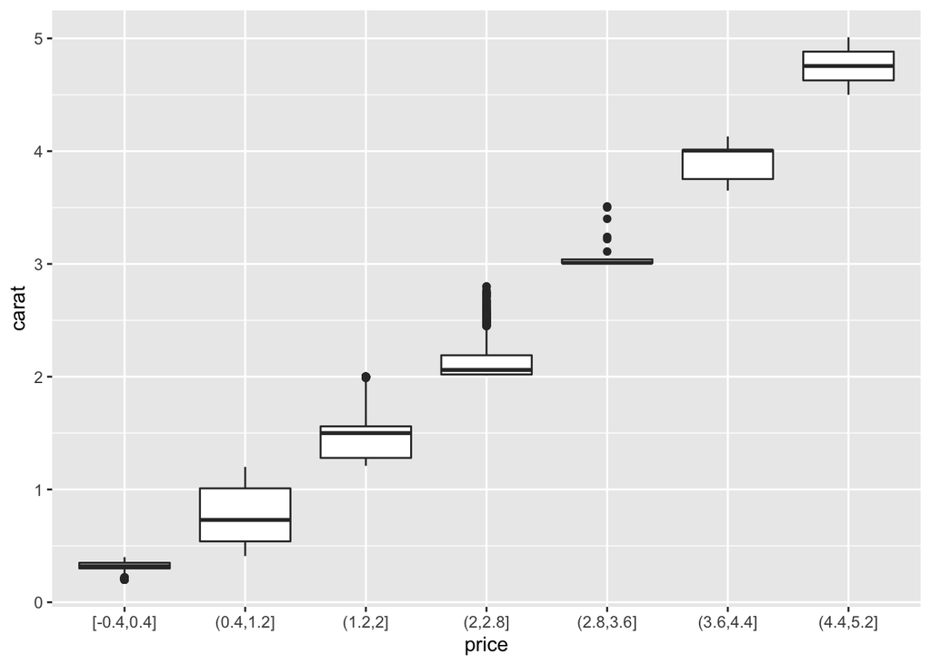

```r
datos <- diamonds
#Variable más importante para determinar el precio de un diamante
#Carat sobre price
ggplot(data = diamonds, mapping = aes(x = price, y =carat)) +
  geom_boxplot(mapping = aes(cut_width(carat , 0.8)), orientation = "x")
```

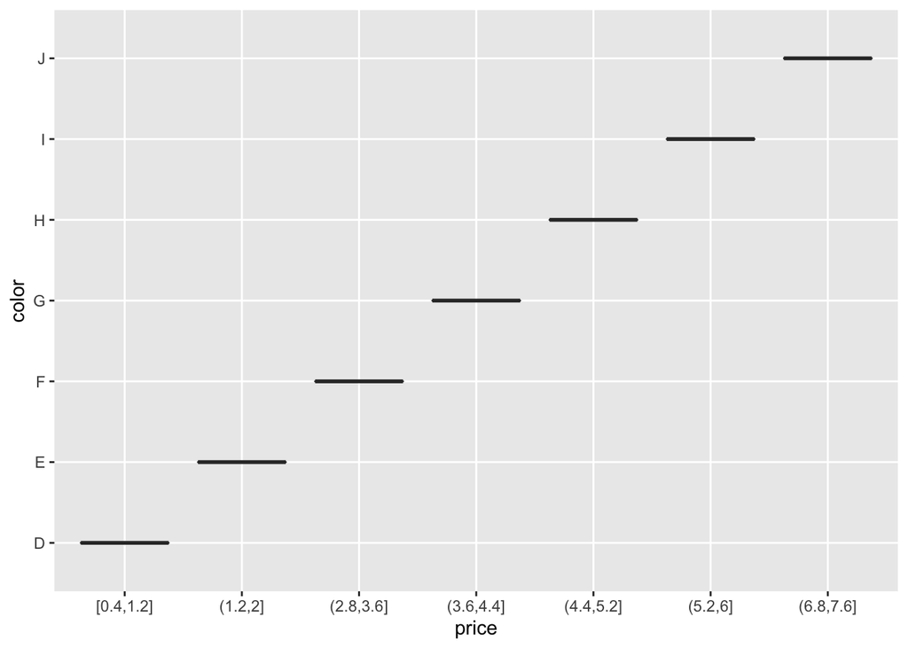

```r
#Color sobre price
ggplot(data = diamonds, mapping = aes(x = price, y =color)) +
  geom_boxplot(mapping = aes(cut_width(color , 0.8)), orientation = "x")
```

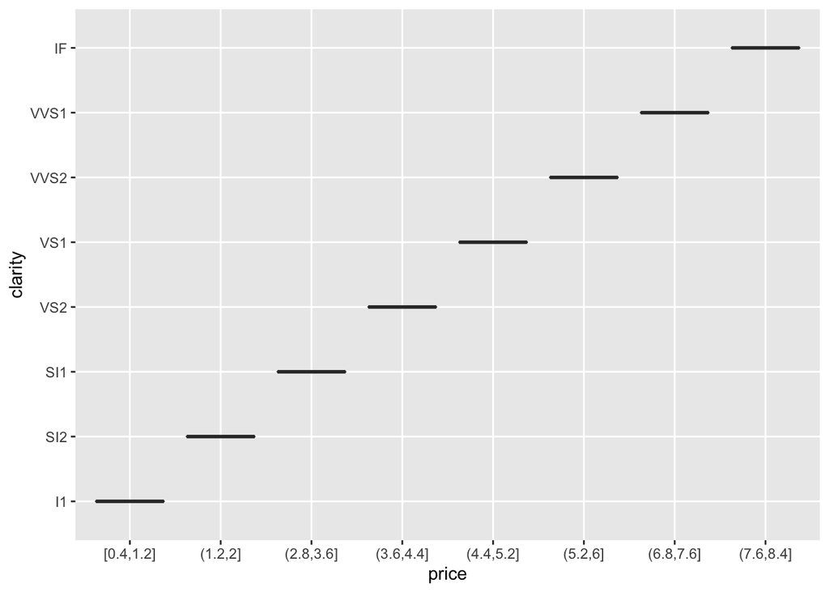

```r
#Clarity sobre price
ggplot(data = diamonds, mapping = aes(x = price, y =clarity)) +
  geom_boxplot(mapping = aes(cut_width(clarity , 0.8)), orientation = "x")
```